# Wine Dataset- Part B - R

**Reading the data from file**

```r
wine <- read.csv(file = 'C:/Users/chakr/Downloads/winequality-red.csv', sep=";")
attach(wine)
```

## **1. Suppose the population mean of the variable “density” is µ , do the following inferences:**

**a. Provide an estimate of µ based on the sample**

```r
mu.hat <- mean(density)
mu.hat
```

```
[1] 0.9967467
```

**Answer -** The estimate of mean from the sample of 1599 observations is 0.9967467. As the population is defined as all the red wines produced in the north of Portugal, we use the given 1599 observations as the sample.

**b. Use the Central Limit Theorem (CLT) to quantify the variability of your estimate**

```r
sd.mu.hat <- sd(density)/sqrt(length(density))
mu_clt.hat <- mean(density)
sd.mu.hat
```

```
[1] 4.71981e-05
```

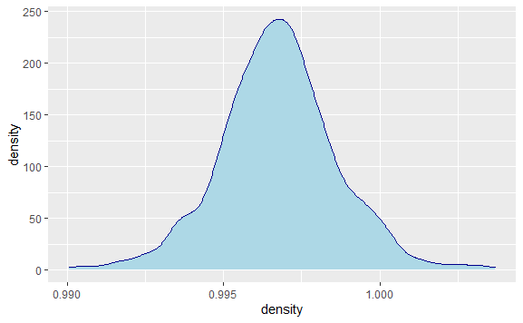

```r
library("ggplot2")
ggplot(data.frame(density), aes(x=density))+
  geom_density(color="darkblue", fill="lightblue")
```

**Answer -** The variability of the above estimate in the first question is the standard deviation by the square root of n, where n is the sample size. The value for variability is found to be 4.71981e-05. The distribution follows a normal distribution.

**c. Use the CLT to give a 95% confidence interval for µ**

```r
c(mu_clt.hat-2*sd.mu.hat, mu_clt.hat+2*sd.mu.hat)
```

```
[1] 0.9966523 0.9968411
```

**Answer -** The 95% confidence interval is given by mu.hat+/- 2xsigma.hat. From the previously calculated value of mu.hat and sd.hat we will calculate the 95% confidence interval which ranges from **0.9966523** to **0.9968411**.

**d. Use the bootstrap method to do parts b and c, and compare the results with those obtained from the CLT. State your findings.**

```r
mu_b.hat.set<-NULL
for(k in 1:4500){
sample.bootstrap<-sample(density, size=1599, replace=T)
mu_b.hat.set[k]<-mean(sample.bootstrap)
}
sd(mu_b.hat.set)
```

```
[1] 4.715365e-05
```

```r
mean(mu_b.hat.set)
```

```
[1] 0.9967471
```

**The quantile ranges for 95% confidence interval are:**

```r
mu_b.ci <- quantile(mu_b.hat.set, prob=c(.025,.975))
mu_b.ci
```

```
     2.5%     97.5%
0.9966547 0.9968406
```

**The confidence intervals are 0.9966547 and 0.9968406.**

```r
tab <- matrix(c(sd(mu_b.hat.set), mean(mu_b.hat.set), sd.mu.hat, mu_clt.hat), ncol=2, byrow=TRUE)
colnames(tab) <- c('Standard Deviation','Mean')
rownames(tab) <- c('Bootstrap','CLT')
tab <- as.table(tab)
tab
```

[output not shown]

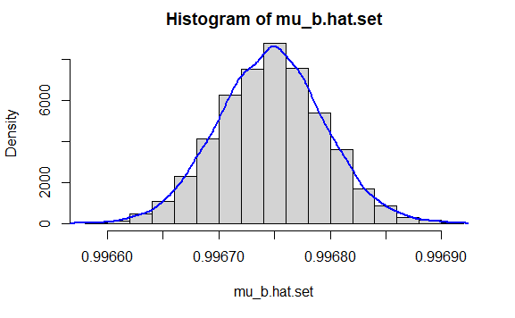

```r
hist(mu_b.hat.set, prob=TRUE)
lines(density(mu_b.hat.set), col="blue", lwd=2)
```

**e. Can we use a normal distribution to model “density”? If yes, what are the maximum likelihood estimates of the mean and standard deviation? Please provide their standard errors as well.**

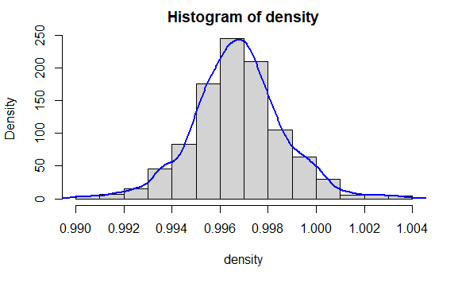

```r
hist(density, prob=TRUE)
lines(density.default(density), col="blue", lwd=2)
```

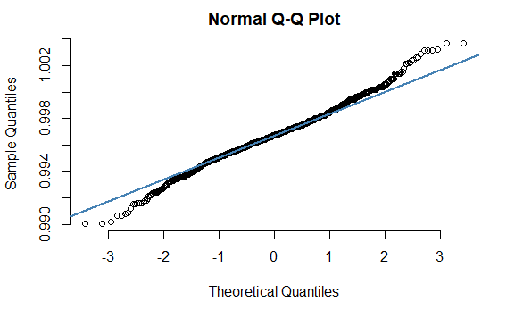

```r
qqnorm(density, frame = FALSE)
qqline(density, col = "steelblue", lwd = 2)
```

```r
library(stats4)
density_scaled <- density*10
log.likelihood<- 0
minuslog.lik<-function(mu, sigma){
  for(i in 1:1599){
log.likelihood <- log.likelihood + log(dnorm(x=density_scaled[i],mean=mu, sd=sigma))
  }
  return(-log.likelihood)
}

est <- mle(minuslog=minuslog.lik, start = list(mu = mean(density_scaled),
                                sigma = sd(density_scaled)))
summary(est)
```

```
Maximum likelihood estimation

Call:
mle(minuslogl = minuslog.lik, start = list(mu = mean(density_scaled),
    sigma = sd(density_scaled)))

Coefficients:
        Estimate   Std. Error
mu    9.96746679 0.0004719810
sigma 0.01887334 0.0003296881

-2 log L: -8159.31
```

**Answer -** The data of density in the wines dataset follows a normal distribution according to the above plots. The maximum likelihood estimates can be found using the the above function. The MLE’s of the mean and standard deviation statistics after transformation are: *Mean : **Estimate*: 0.996746679 ,* Standard Error*: 0.00004719810* Standard Deviation :** Estimate*: 0.001887334 , *Standard Error*: 0.00003296881

## **2. Suppose the population mean of the variable “residual sugar” is µ , answer the following questions.**

**a. Provide an estimate of µ based on the sample;**

```r
mu_residual.hat <- mean(residual.sugar)
mu_residual.hat
```

```
[1] 2.538806
```

**Answer -** The estimate of mean from the sample of 1599 obervations for residual sugar is 2.538806. As the population is defined as all the red wines produced in the north of Portugal, we use the given 1599 observations as the sample.

**b. Noting that the sample distribution of “residual sugar” is highly skewed, can we use the CLT to quantify the variability of your estimate? Can we use the CLT to give a 95% confidence interval for µ? If yes, please give your solution. If no, explain why.**

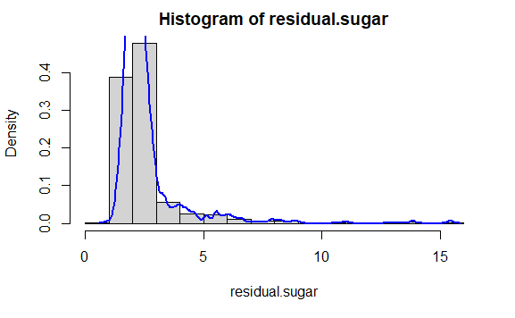

```r
hist(residual.sugar, prob=TRUE)
lines(density(residual.sugar), col="blue", lwd=2)
```

**Answer -** As we can see from the above plot the distribution for residual sugar is highly positively skewed. But as CLT follows that the sample means will be normally distributed even though the population is not normally distributed, therefore we can use CLT to quantify the variability of the above estimate of the mean.

```r
sd.mu_residual.hat <- sd(residual.sugar)/sqrt(length(residual.sugar))
mu_residual_clt.hat <- mean(residual.sugar)
sd.mu_residual.hat
```

```
[1] 0.03525922
```

**Answer -** The CLT gives us that the variability of the data is 0.03525922.

```r
c(mu_residual_clt.hat-2*sd.mu_residual.hat, mu_residual_clt.hat+2*sd.mu_residual.hat)
```

```
[1] 2.468287 2.609324
```

**Answer -** The 95% confidence interval is given by mu.hat+/- 2xsigma.hat. From the previously calculated value of mu.hat and sd.hat we will calculate the 95% confidence interval which ranges from **2.468287** to **2.609324**.

**c. Use the bootstrap method to do part b. Is the bootstrap confidence interval symmetric?**

```r
mu_residual_boot.hat.set<-NULL
for(k in 1:4500){
residual.bootstrap<-sample(residual.sugar, size=1599, replace=T)
mu_residual_boot.hat.set[k]<-mean(residual.bootstrap)
}
sd(mu_residual_boot.hat.set)
```

```
[1] 0.03514217
```

```r
mean(mu_residual_boot.hat.set)
```

```
[1] 2.539469
```

The quantile ranges for 95% confidence interval are:

```r
mu_b_residual.ci <- quantile(mu_residual_boot.hat.set, prob=c(.025,.975))
mu_b_residual.ci
```

```
    2.5%    97.5%
2.472623 2.609916
```

**Answer -** The confidence intervals are **2.472623** and **2.609916**.

```r
tab <- matrix(c(sd(mu_residual_boot.hat.set), mean(mu_residual_boot.hat.set), sd.mu_residual.hat, mu_residual_clt.hat), ncol=2, byrow=TRUE)
colnames(tab) <- c('Standard Deviation','Mean')
rownames(tab) <- c('Bootstrap','CLT')
tab <- as.table(tab)
tab
```

```
          Standard Deviation       Mean
Bootstrap         0.03514217 2.53946929
CLT               0.03525922 2.53880550
```

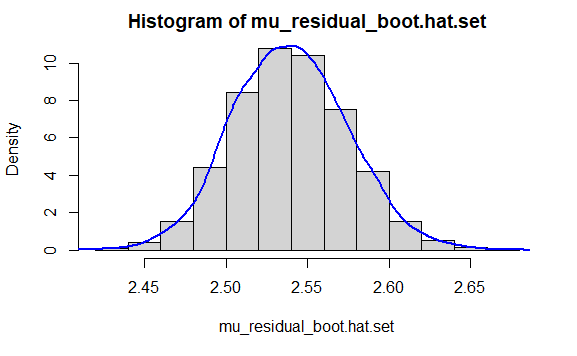

```r
hist(mu_residual_boot.hat.set, prob=TRUE)
lines(density(mu_residual_boot.hat.set), col="blue", lwd=2)
```

**Answer -** Yes the bootstrap is symmetric around the confidence interval.

**d. Can we use a normal distribution to model “residual sugar”? If no, what distribution do you think can approximate its empirical distribution? What parameters are needed to characterize such a distribution? what are their maximum likelihood estimates? Please provide their standard errors as well.**

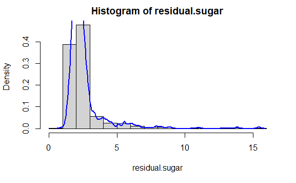

```r
hist(residual.sugar, prob=TRUE)
lines(density.default(residual.sugar), col="blue", lwd=2)
```

**Answer -** No we cannot model residual sugar using the normal distribution as the data is heavily positively skewed.  
Instead in this case we can use the Log-Normal Distribution which can be used to approximate its empirical distribution, as by theoretical definition its a distribution that is normally distributed if the logarithm is normally distributed. The parameters needed to characterize such a distribution is the mean and the standard deviation.

```r
options(warn=-1)
log.likelihood<- 0
minuslog.lik<-function(mu, sigma){
  for(i in 1:1599){
log.likelihood <- log.likelihood + log(dlnorm(x=residual.sugar[i],meanlog=mu, sdlog=sigma))
  }
  return(-log.likelihood)
}

est <- mle(minuslog=minuslog.lik, start = list(mu = log(mean(residual.sugar)), sigma = log(sd(residual.sugar))))
summary(est)
```

```
Maximum likelihood estimation

Call:
mle(minuslogl = minuslog.lik, start = list(mu = log(mean(residual.sugar)),
    sigma = log(sd(residual.sugar))))

Coefficients:
       Estimate  Std. Error
mu    0.8502341 0.008935942
sigma 0.3573260 0.006318293

-2 log L: 3965.773
```

## **3. We classify those wines as “excellent” if their rating is at least 7. Suppose the population proportion of excellent wines is p. Do the following:**

**a. Use the CLT to derive a 95% confidence interval for p**

```r
excellent <- as.numeric(quality >= 7)
```

Calculation p :

```r
p <- mean(excellent)
p
```

```
[1] 0.1357098
```

Calculating standard deviation:

```r
std_quality <- sqrt(p*(1-p)/length(excellent))
std_quality
```

```
[1] 0.008564681
```

```r
c(p-2*std_quality, p+2*std_quality)
```

```
[1] 0.1185805 0.1528392
```

**Answer -** The 95% confidence interval is given by mu.hat+/- 2*sigma.hat. From the previously calculated value of mu.hat and sd.hat we will calculate the 95% confidence interval which ranges from 0.1185805 to 0.1528392.

**b. Use the bootstrap method to derive a 95% confidence interval for p**

```r
mu_p_boot.hat.set<-NULL
for(k in 1:4500){
excellent.bootstrap<-sample(excellent, size=1599, replace=T)
mu_p_boot.hat.set[k]<-mean(excellent.bootstrap)
}
sd(mu_p_boot.hat.set)
```

```
[1] 0.008576993
```

```r
mean(mu_p_boot.hat.set)
```

```
[1] 0.1358482
```

The quantile ranges for 95% confidence interval are:

```r
mu_b_excellent.ci <- quantile(mu_p_boot.hat.set, prob=c(.025,.975))
mu_b_excellent.ci
```

```
     2.5%     97.5%
0.1188243 0.1532208
```

**Answer-** The confidence intervals after bootstrap are 0.1188243 and 0.1532208.

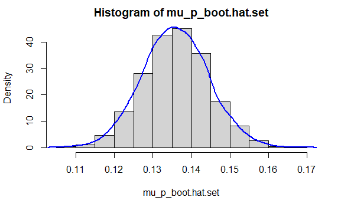

```r
hist(mu_p_boot.hat.set, prob=TRUE)
lines(density(mu_p_boot.hat.set), col="blue", lwd=2)
```

**c. Compare the two intervals. Is there any difference worth our attention?**

Both the confidence intervals are similar and therefore there is no difference worth our attention.

**d. What is the maximum likelihood estimate of p and its standard error?**

```r
log.likelihood<- 0
minuslog.lik<-function(p){
  for(i in 1:1599){
log.likelihood <- log.likelihood + log(dbinom(excellent[i], size=1, prob=p))
  }
  return(-log.likelihood)
}

est <- mle(minuslog=minuslog.lik, start = list(p = p))
summary(est)
```

```
Maximum likelihood estimation

Call:
mle(minuslogl = minuslog.lik, start = list(p = p))

Coefficients:
   Estimate  Std. Error
p 0.1357098 0.008564278

-2 log L: 1269.921
```

**Answer -** The maximum likelihood estimates can be found using the the above function. The MLE’s of p are: **p :** *Estimate*: 0.1357098 , *Standard Error*: 0.008564278